# Priapism and Erectile Dysfunction

Monica Rivera

12-09-2025

## Introduction

The **Erectile Dysfunction and Pyschosocial Outcomes Following Priapism Treatment: A Retrospective Study** was conducted at Korle Bu Teaching Hospital in Accra, Ghana. The data collected from this study includes anonymous information on male patients treated for priapism between October 30, 2015 to January 8, 2023.

**Contents**:

- **Demographics** - age, age at first priapism episode, sickle cell disease status
- **Clinical characteristics** - etiology of priapism, treatment modalities, time to treatment
- **Erectile dysfunction (ED) severity** - measured through the International Index of Erectile Function (IIEF-5) score
- **Psycho social outcomes** - relational, psycho social, reproductive impacts

## Analysis Objective

Investigate the relationship between patient characteristics using the IIEF-5 score as a measure of erectile function.

## Descriptive Statistics

**Table 1. Summary Statistics of Study Participants**

| **Characteristic** | **N = 65**<sup>1</sup> |
| --- | --- |
| Age (years) | 35 (8) |
| Age at 1st Episode | 31 (8) |
| IIEF-5 Score | 16 (7) |
| Number of Priapism Episodes |  |
| 1 | 38 (58%) |
| 2 | 16 (25%) |
| 3 | 3 (4.6%) |
| 4 | 2 (3.1%) |
| 5 | 2 (3.1%) |
| 6 | 1 (1.5%) |
| 7 | 1 (1.5%) |
| 10 | 2 (3.1%) |
| ED Severity |  |
| 1 | 17 (26%) |
| 2 | 17 (26%) |
| 3 | 15 (23%) |
| 4 | 5 (7.7%) |
| 5 | 11 (17%) |

<sup>1</sup> Mean (SD); n (%)

Table 1 shows the average age, age at first priapism episode, IIEF-5 score, number of episodes, and erectile dysfunction severity of the 65 patients.

## Data Visualization

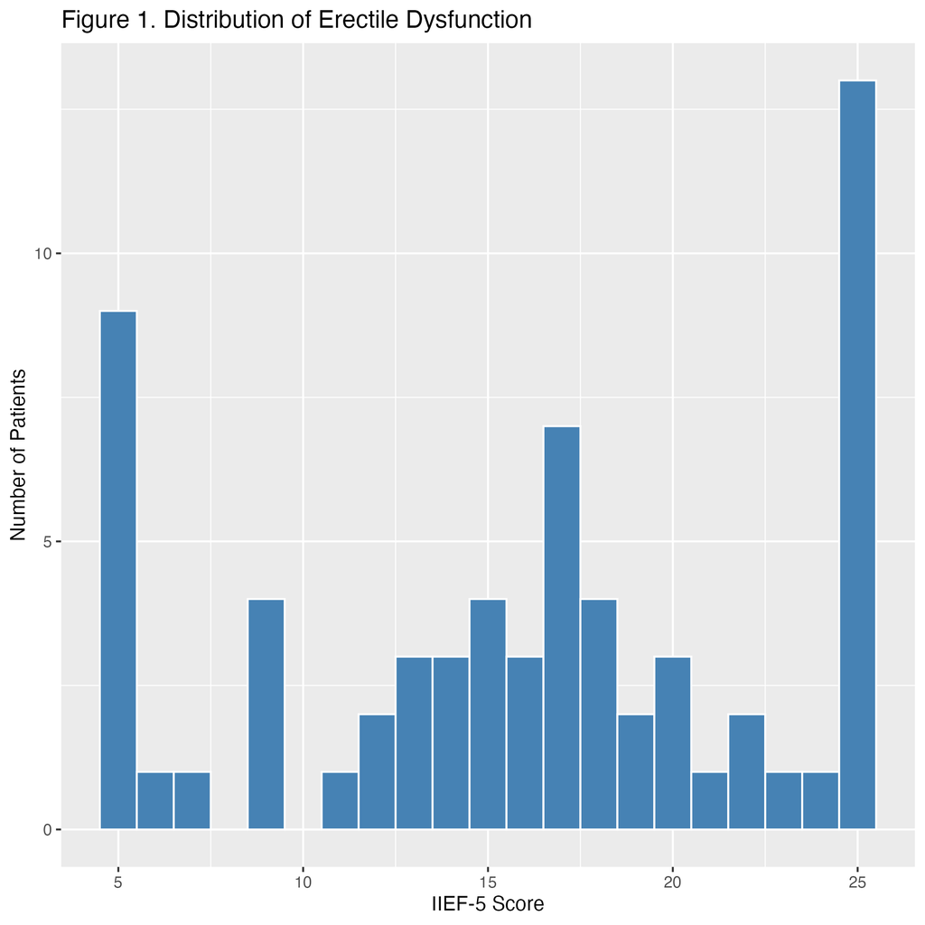

Figure 1 illustrates the distribution of IIEF-5 scores in the cohort. Lower scores suggest more severe erectile dysfunction, while higher scores indicate better erectile function. This figure allows us to quickly assess how erectile function is distributed among the patients studied.